# Re-Analysis of Ruggeri et al 2022 (Pre-submission)

Hu Chuan-Peng

This is a [R Markdown](http://rmarkdown.rstudio.com) Notebook for re-analyzing the sample in paper [The globalizability of temporal discounting](https://www.nature.com/articles/s41562-022-01392-w).

Aim: Illustrate the representativeness of samples from US, China, and Nigeria in [Ruggeri et al (2022, NHB)](https://www.nature.com/articles/s41562-022-01392-w) in terms of gender, age, educational attainment, and geographical distribution.

# Chinese sample

## Preprocessing

We extracted data from Ruggeri et al (2022). Based on the description from the pre-registration, we selected adults data (>=18 yrs old) from Chinese census data.

Excerpt from pre-registration (https://osf.io/jfvh4): *Adult participants from 18 years of age and up (in some countries, 19 or 21 is the minimum age to participate in research) will be recruited from 65 countries, covering 41 languages.*

Here is the description of the participant in the paper:

*The final dataset was composed of 13,629 responses from 61 countries. The original sample size was 25,877, which was reduced almost by half after we performed pre-registered data exclusions. We removed 6,141 participants (23.7%) who did not pass our attention check (a choice between receiving 10% of monthly income now or paying the same amount in one year). We removed 69 participants for presenting nonsensical responses to open data text (for example, ‘helicopter’ as gender). We removed 13 participants claiming to be over 100 years old. We included additional filters to our original exclusion criteria. Regarding the length of time for responses, individuals faster than three times the absolute deviation below the median time or that took less than 120 seconds to respond were removed. This criterion allowed us to identify 5,870 inappropriate responses. We further removed responses from IP addresses identified as either ‘tests’ or ‘spam’ by the Qualtrics service (264 answers identified). Lastly, we did not consider individuals not completing over 90% of the survey (9,434 responses failed this criterion). Note that these values add up to more than 100% because participants could fail multiple criteria.*

```r
### code for preparing census data about education, will not used after saving RData
# df_tmp <- bruceR::import(here::here("A0401_CNH_Census7_Age_education_edited.xls"))  # import data that downloaded from census website
# #
# # # create a list of columns
# edu_colnames <- tidyr::crossing(c("pop", "noSchool", "preSchool", "elementary",
#                                   "middle", "high", "technical", "university", "master", "PhD"),
#                                 c("all", "male", "fmale")) %>%
#   dplyr::rename("edu" = 1, "sex" = 2 ) %>%
#   dplyr::mutate(edu = factor(edu, levels = c("pop", "noSchool", "preSchool", "elementary",
#                                   "middle", "high", "technical", "university", "master", "PhD"))) %>%
#   dplyr::arrange(edu) %>%
#   tidyr::unite(cols, edu:sex, remove = FALSE) %>%
#   dplyr::pull(cols)
#
# colnames(df_tmp) <- c("Age", edu_colnames)
#
# df_census7_edu <- df_tmp %>%
#   dplyr::mutate(Age = ifelse(Age == "85岁及以上", 85, Age)) %>%
#   dplyr::mutate(Age = as.numeric(Age)) %>%
#   dplyr::filter(!is.na(Age))

# df_census7_edu <- df_census7_edu %>% rename_with( ~ gsub("_fmale", "_female", .x, fixed = TRUE))  # replace "fmale" with "female"

# save(df_census7_age, df_census7_edu, file = here::here("CHN_Census.RData"))

#
# Reg_Name_EN <- c("Whole_Country_Mainland", "Beijing", "Tianjin", "Hebei", "Shanxi", "Inner Mongolia", "Liaoning",
#                  "Jilin", "Heilongjiang", "Shanghai", "Jiangsu", "Zhejiang", "Anhui", "Fujian", "Jiangxi", "Shandong",
#                  "Henan", "Hubei", "Hunan", "Guangdong", "Guangxi", "Hainan", "Chongqing", "Sichuan", "Guizhou",
#                  "Yunnan", "Tibet", "Shaanxi", "Gansu", "Qinghai", "Ningxia", "Xinjiang")
#
# df_tmp <- bruceR::import(here::here("A0105_region_age_sex_edited.xls"))  # import data that downloaded from census website
#
# newColNames <- colnames(df_tmp)
# newColNames <- gsub("岁", "years", newColNames)
# newColNames <- gsub("及以上", "", newColNames)
# newColNames <- gsub("-", "_", newColNames)
# newColNames[c(1,2)] <- c( "Regions", "All")
#
# newColNames2 <- NULL
#
# for (ii in 1:length(newColNames)){
#   # if contain ".."
#   if (grepl("...", newColNames[ii], fixed=TRUE)){
#     #print(newColNames[ii])
#     # extract the number
#     tmp_num <- as.numeric(gsub("...", "", newColNames[ii]))
#     print(tmp_num)
#
#     # ii-1 does not contain "...", male, else, female
#     if (!grepl("...", newColNames[ii-1], fixed=TRUE)){
#       # add female to the column name
#       # print()
#       tmp_name <- paste(newColNames[ii-1], "male", sep = "_")
#     } else{
#       tmp_name <- paste(newColNames[ii-2], "female", sep = "_")
#     }
#     print(tmp_name)
#     newColNames2[ii] <- tmp_name
#   }else{
#     newColNames2[ii] <- newColNames[ii]
#   }
# }
#
# colnames(df_tmp) <- newColNames2
#
# df_census7_geo <- df_tmp %>%
#   dplyr::filter(!is.na(Regions)) %>%
#   dplyr::mutate(Regions = stringr::str_squish(Regions),
#                 Regions_EN = Reg_Name_EN) %>%
#   dplyr::rename(Regions_CN=Regions)

# save.image(file =  here::here("Re_Analysis_CHN.RData"))
# df_cn_census <- df_cn_census_edu
# df_cn_ruggeri2022 <- dat_cn
# df_cn_census_geo <- df_census7_geo
# save(df_cn_census, df_cn_census_geo, ChinaMap, China_border_line, colour, file = here::here("Re_Analysis_CHN.RData"))

# Load pre-processed census data and data from Ruggeri et al 2022, not that the largest age means >= that value

# load the data from Ruggeri 2022, it includes three variables:
# "dat_filter", "dat_item", "dat_unique"
load(here::here("1_2_data_files.RData"))

# load data for Chinese sample, it includes five variables:
# "China_border_line", "ChinaMap", "colour","df_cn_census", "df_cn_census_geo"
load(here::here("Re_Analysis_CHN.RData"))
# province <- bruceR::import("CHNMap/province3.csv")    # for geo plot
# colour   <- bruceR::import("CHNMap/colour4.csv")      # for geo plot

# import data for Nigeria, it includes two variable:
# "df_ng_wb": data extracted from World Bank, df_ng_wb <- bruceR::import('Data_extracte_WorldBankData_Series_Data.csv')
load(here::here("Re_Analysis_NG.RData"))
# the two files below are also needed
# "NG_pop_2019_wiki.csv"  # for geo
# "Re_Analysis_NG.RData"  # for geo plot
# save(df_ng_map, df_ng_wb, file = here::here("Re_Analysis_NG.RData"))

# load data for US, which include one variable "df_us_map"
load(here::here("Re_Analysis_USA.RData"))    # for geo plots
# "ACSST5Y2021.S0101-2023-02-08T075713.csv"
# "ACSDT5Y2021.B15001-2023-02-08T135043.csv"
# "DECENNIALPL2020.P1-2023-02-08T080125.csv"
```

Total number of participants in China is n = 398.

## Sex & Age (pyramids plots)

Note that here we used only “female” and “male” to quickly check the data.

```r
df_cn_ruggeri2022 <- dat_unique %>%
  dplyr::filter(Residence == "China") %>%
  dplyr::select(ResponseId, Gender, EducationCompleted, Residence, Age, "Ethnic", "REGION" )

df_cn_ruggeri2022_sex <- df_cn_ruggeri2022 %>%
  dplyr::filter(Gender == "Female" | Gender == "Male") %>%
  dplyr::count(Gender) %>%
  dplyr::mutate(Proportion = round(n / sum(n), 2) * 100,
                Site = "Ruggeri_2022") %>%
  dplyr::select(Site, Gender, Proportion) %>%
  dplyr::rename(Sex = Gender)

df_cn_census_sex <- df_cn_census %>%
  dplyr::filter(Age >= 18) %>%
  dplyr::select(pop_female, pop_male) %>%
  dplyr::mutate_if(is.character, as.numeric) %>%
  colSums() %>%
  data.frame() %>%
  dplyr::rename(N=".") %>%
  dplyr::mutate(Sex = rownames(.)) %>%
  dplyr::mutate(Sex = ifelse(Sex == "pop_female", "Female", "Male")) %>%
  dplyr::mutate(Proportion = N/sum(N)) %>%
  dplyr::mutate(Site = "Census7") %>%
  dplyr::select(Site, Sex, Proportion) %>%
  dplyr::mutate(Proportion = round(as.numeric(Proportion*100), 0)) %>%
  `rownames<-` (NULL)

df_cn_sex_ratio <- rbind(df_cn_ruggeri2022_sex, df_cn_census_sex)

fig1a <- ggplot(df_cn_sex_ratio, aes(Site, Proportion,fill=Sex)) +
  geom_col(alpha = 0.5) +
  theme_classic()+
  xlab("Data sources") +
  theme(legend.position = "none",
        # legend.key.size = unit(20,"pt"),
        # legend.box.spacing = unit(4,"pt"),
        # legend.title = element_blank(),
        axis.title = element_text(size = 16, family = "serif"),
        # legend.text = element_text(size = 16, family = "serif"),
        axis.text = element_text(size =16, family = "serif"))

fig1a
```

### Age bins

The age bins were tailored so it start with 17 years old.

```r
df_cn_ruggeri2022_age <- df_cn_ruggeri2022 %>%
  dplyr::filter(!is.na(Age)) %>%
  dplyr::mutate(ageBins_pyr = cut(Age,
                                  breaks=c(17, 22, 27, 32, 37, 42, 47,
                                           52, 57,62, 67, Inf),
                                  labels=c("17~21", "22~26", "27~31", "32~36", "31~41", "42~46",
                                           "47~51","52~56","57~61","62~66",">=67")),
                ageBins_pyr = factor(ageBins_pyr,
                                     levels = c("17~21", "22~26", "27~31", "32~36", "31~41", "42~46",
                                                "47~51","52~56","57~61","62~66", ">=67"))) %>%
  dplyr::mutate(Sex = as.character(Gender)) %>%
  dplyr::filter(Sex == "Female" | Sex == "Male") %>%
  dplyr::count(ageBins_pyr, Sex) %>%
  dplyr::mutate(Proportion = round(n / sum(n), 4) * 100) %>%
  tidyr::complete(ageBins_pyr, Sex, fill=list(Proportion=0)) %>%
  dplyr::mutate(Site = "Ruggeri_etal_2022",
                Sex = ifelse(Sex == "Female", "female_R", "male_R"))

df_cn_census_age <- df_cn_census %>%
  dplyr::filter(Age >= 18) %>%
  dplyr::select(Age, pop_female, pop_male) %>%
  dplyr::mutate_if(is.character, as.numeric) %>%
  dplyr::rename(Female = pop_female, Male=pop_male) %>%
  tidyr::pivot_longer(cols = c(Male, Female),
                      names_to = "Sex",
                      values_to = "N") %>%
  dplyr::mutate(ageBins = cut(Age,
                              breaks=c(17, 22, 27, 32, 37, 42, 47,
                                           52, 57,62, 67, Inf),
                              labels=c("17~21", "22~26", "27~31", "32~36", "31~41", "42~46",
                                           "47~51","52~56","57~61","62~66",">=67")),
                ageBins = factor(ageBins,
                                 levels = c("17~21", "22~26", "27~31", "32~36", "31~41", "42~46",
                                           "47~51","52~56","57~61","62~66",">=67"))) %>%
  dplyr::group_by(Sex, ageBins) %>%
  dplyr::summarise(N_sum = sum(N)) %>%
  dplyr::ungroup() %>%
  dplyr::mutate(Proportion = round(N_sum / sum(N_sum), 4) * 100) %>%
  tidyr::complete(ageBins, Sex, fill=list(Proportion=0))

### Plotting
fig1b <- ggplot(data= df_cn_census_age, aes(x=ageBins, y=ifelse(Sex=="Male", -Proportion, Proportion), fill=Sex)) +
  geom_col(alpha=0.5, width = 1) +
  geom_line(data = df_cn_ruggeri2022_age, aes(x=ageBins_pyr,
                                      y = ifelse(Sex == "male_R", -Proportion, Proportion),
                                      group=Sex,color="Ruggeri2022"), size=1, inherit.aes = FALSE) +
  # scale_y_continuous(limits = c(-15,15), sec.axis = sec_axis(~.*1, name = "Proportion (Ruggeri2022)")) +
  coord_flip() +
  labs(y="Proportion", x = "Age bins", color=NULL)+
  annotate("text",label= "italic(Male)", x=10,y=-3, parse=TRUE,size=8, family = "serif") +
  annotate("text",label= "italic(Female)", x=10,y=4, parse=TRUE,size=8,family = "serif") +
  scale_color_manual(values = c("red","blue"))+
  theme_classic()+
  theme(panel.border =element_rect(fill=NA,color="black"),
        legend.position ="bottom",
        legend.box.spacing = unit(2,"pt"),
        legend.text = element_text(size = 16, family = "serif"),
        legend.title = element_blank(),
        axis.title = element_text(size = 16,family = "serif"),
        axis.text = element_text(size = 16,family = "serif"))
fig1b
```

## Education

The coding of education in Census data and in Ruggeri et al. (2022) is different:

In the census data, there are 9 levels for educational attainment: “no school”, “pre school”, “primary school”, “middle school”, “high school”, “Technical college”, `Bachelor`, `Master`, and `PhD`.

In Ruggeri et al. (2022), there are seven levels and `graduate` and `MBA` were treated as different degree: `Primary ed.`, `Secondary ed.`, `Technical ed.`, `Bachelor`, `MBA`, `Graduate`, and `PhD`.

```r
df_cn_census_edu <- df_cn_census %>%
  dplyr::filter(Age >= 18) %>%
  dplyr::select(-ends_with("_all")) %>%
  dplyr::select(-starts_with("pop_")) %>%
  dplyr::mutate_if(is.character, as.numeric) %>%
  tidyr::pivot_longer(cols = noSchool_female: PhD_male,
                      names_to = "Edu_Sex",
                      values_to = "N") %>%
  tidyr::separate(Edu_Sex, c("Edu", "Sex")) %>%
  dplyr::group_by(Edu, Sex) %>%
  summarise(N_pop = sum(N)) %>%
  dplyr::ungroup() %>%
  dplyr::mutate(Edu = dplyr::case_when(Edu == "preSchool" | Edu == "noSchool" ~ "NoSchool",
                                       Edu == "elementary" ~ "Primary",
                                       Edu == "middle" | Edu == "high" ~ "Secondary",
                                       Edu == "technical" ~ "Technical",
                                       Edu == "university" ~ "Bachelor",
                                       Edu == "master" | Edu == "PhD" ~ "Graduate",
                                       TRUE ~ "Other"
                                       ),
                Edu = factor(Edu, levels = c("NoSchool", "Primary", "Secondary", "Technical",
                                             "Bachelor", "Graduate")),
                Sex = ifelse(Sex == "female", "Female", "Male"),
                Sex = factor(Sex, levels = c("Female", "Male"))) %>%
  dplyr::group_by(Sex, Edu) %>%
  dplyr::summarise(N = sum(N_pop)) %>%
  dplyr::ungroup()  %>%
  tidyr::complete(Sex, Edu, fill = list(N=0)) %>%
  dplyr::mutate(Proportion = round(N / sum(N), 4) * 100)

## Prepare data from Ruggeri et al (2022)
df_cn_ruggeri2022_edu <- df_cn_ruggeri2022 %>%
  dplyr::rename(Edu = EducationCompleted,
                Sex = Gender) %>%
  dplyr::filter(Sex == "Male" | Sex == "Female") %>%
  dplyr::mutate(Edu = dplyr::case_when(Edu == "preSchool" | Edu == "noSchool" ~ "NoSchool",
                                       Edu == "Primary ed." ~ "Primary",
                                       Edu == "Secondary ed." ~ "Secondary",
                                       Edu == "Technical ed." ~ "Technical",
                                       Edu == "Bachelor" ~ "Bachelor",
                                       Edu == "Graduate" | Edu == "MBA" | Edu == "PhD" ~ "Graduate",
                                           TRUE ~ "Other"
                                       ),
                Edu = factor(Edu, levels = c("NoSchool", "Primary", "Secondary", "Technical",
                                             "Bachelor", "Graduate")),
                Sex = factor(Sex, levels = c("Female", "Male"))) %>%
  dplyr::group_by(Sex, Edu) %>%
  dplyr::summarise(N = n()) %>%
  dplyr::ungroup() %>%
  tidyr::complete(Sex, Edu, fill = list(N=0)) %>%
  dplyr::mutate(Proportion = round(N / sum(N), 4) * 100)

fig1c <- ggplot(data= df_cn_census_edu,
                aes(x=Edu, y=ifelse(Sex=="Male", -Proportion, Proportion), fill=Sex)) +
  geom_col(alpha=0.5, width = 1) +
  geom_line(data = df_cn_ruggeri2022_edu,
            aes(x=Edu,
                y = ifelse(Sex == "Male", -Proportion, Proportion),
                group=Sex, color="Ruggeri2022"), size=1, inherit.aes = FALSE) +
  # scale_y_continuous(limits = c(-15,15), sec.axis = sec_axis(~.*1, name = "Proportion (Ruggeri2022)")) +
  coord_flip() +
  labs(y="Proportion", x = "Education attainments", color=NULL) +
  annotate("text",label= "italic(Male)", x=6,y=-11, parse=TRUE,size=8, family = "serif") +
  annotate("text",label= "italic(Female)", x=6,y=11, parse=TRUE,size=8,family = "serif") +
  scale_color_manual(values = c("red","blue")) +
  theme_classic() +
  theme(panel.border =element_rect(fill=NA,color="black"),
        legend.position ="bottom",
        legend.box.spacing = unit(2,"pt"),
        legend.text = element_text(size = 16, family = "serif"),
        legend.title = element_blank(),
        axis.title = element_text(size = 16,family = "serif"),
        axis.text = element_text(size = 16,family = "serif"))

fig1c
```

## Geographical distribution

After examining the proportion of data from each province, we have the following seven levels:

- > 25%
- 20% ~ 24.9%
- 15% ~ 19.9%
- 10% ~ 14.9%
- 5% ~ 9.9%
- 1% ~ 4.9%
- < 1%

We used these levels to color the map.

```r
df_cn_census_geo_adults <- df_cn_census_geo %>%
  dplyr::select(Regions_CN, 17:ncol(.)) %>%
  dplyr::select(Regions_CN, Regions_EN, everything()) %>%
  dplyr::mutate_at(c(3:56), as.numeric) %>%
  dplyr::filter(Regions_EN != "Whole_Country_Mainland")

df_cn_census_geo_adults_all <- df_cn_census_geo_adults %>%
  dplyr::select(-contains("male")) %>%
  dplyr::mutate(N = rowSums(across(where(is.numeric)))) %>%
  dplyr::select(Regions_CN, Regions_EN,N) %>%
  dplyr::mutate(Proportion = round(N / sum(N), 3) * 100) %>%
  dplyr::mutate(PropBins = cut(Proportion,
                              breaks=c(0, 1, 5, 10, 15, 20, 25, 30),
                              labels=c("< 0.9%", "1~4.9%", "5~9.9%", "10~14.9%", "15~19.9%",
                                       "20~24.9%",">25%")),
                PropBins = factor(PropBins,
                                  levels = c("< 0.9%", "1~4.9%", "5~9.9%", "10~14.9%", "15~19.9%",
                                             "20~24.9%",">25%")),
                Colors = cut(Proportion,
                             breaks=c(0, 1, 5, 10, 15, 20, 25, 30),
                             labels=c("1", "2", "3", "4", "5","6","7")),
                Colors = factor(Colors,
                                levels = c("0","1", "2", "3", "4", "5","6","7"))
                ) %>%
  dplyr::arrange(desc(Regions_CN))

df_cn_census_geo_adults_female <- df_cn_census_geo_adults %>%
  dplyr::select(Regions_CN, Regions_EN, contains("female")) %>%
  dplyr::mutate(N_female = rowSums(across(where(is.numeric)))) %>%
  dplyr::select(Regions_CN, Regions_EN, N_female)

df_cn_census_geo_adults_male <- df_cn_census_geo_adults %>%
  dplyr::select(Regions_CN, Regions_EN, contains("_male")) %>%
  dplyr::mutate(N_male = rowSums(across(where(is.numeric)))) %>%
  dplyr::select(Regions_CN, Regions_EN, N_male)

df_cn_census_geo_adults_sex <- df_cn_census_geo_adults_female %>%
  dplyr::left_join(., df_cn_census_geo_adults_male) %>%
  tidyr::pivot_longer(c(N_female, N_male), names_to = "Sex", values_to = "N") %>%
  dplyr::mutate(Sex = gsub("N_", "", Sex),
                Sex = ifelse(Sex == "female", "Female", "Male"),
                Proportion = round(N / sum(N), 3) * 100)  %>%
  dplyr::mutate(Regions_EN = factor(Regions_EN,
                                    levels = df_cn_census_geo_adults_all$Regions_EN))
df_cn_ruggeri2022_geo_sex <- df_cn_ruggeri2022 %>%
  dplyr::rename(Regions_EN = REGION, Sex=Gender) %>%
  dplyr::filter(Sex == "Female" | Sex=="Male") %>%
  dplyr::group_by(Regions_EN, Sex) %>%
  dplyr::summarise(N = n()) %>%
  dplyr::ungroup() %>%
  dplyr::filter(!is.na(Regions_EN)) %>%
  dplyr::filter(Regions_EN != "Other") %>%
  dplyr::arrange(N) %>%
  dplyr::mutate(Proportion = round(N / sum(N), 3) * 100,
                Regions_EN = factor(Regions_EN,
                                    levels = df_cn_census_geo_adults_all$Regions_EN))
# similar plot as for age and educational attainment, but this fig does not suit other countries, not presented in the end.
ggplot(data= df_cn_census_geo_adults_sex,
                aes(x=Regions_EN, y=ifelse(Sex=="Male", -Proportion, Proportion), fill=Sex)) +
  geom_col(alpha=0.5, width = 1) +
  geom_line(data = df_cn_ruggeri2022_geo_sex,
            aes(x=Regions_EN,
                y = ifelse(Sex == "Male", -Proportion, Proportion),
                group=Sex, color="Ruggeri2022"), size=1, inherit.aes = FALSE) +
  # scale_y_continuous(limits = c(-15,15), sec.axis = sec_axis(~.*1, name = "Proportion (Ruggeri2022)")) +
  coord_flip() +
  labs(y="Proportion", x = "Provinces (China Mainland)", color=NULL) +
  annotate("text",label= "italic(Male)", x=30,y=-3, parse=TRUE,size=8, family = "serif") +
  annotate("text",label= "italic(Female)", x=30,y=3, parse=TRUE,size=8,family = "serif") +
  scale_color_manual(values = c("red","blue")) +
  theme_classic() +
  theme(panel.border =element_rect(fill=NA,color="black"),
        legend.position ="bottom",
        legend.box.spacing = unit(2,"pt"),
        legend.text = element_text(size = 16, family = "serif"),
        legend.title = element_blank(),
        axis.title = element_text(size = 16,family = "serif"),
        axis.text = element_text(size = 16,family = "serif"))

### preparing the map

# count the number of participants in each province
df_cn_ruggeri2022_geo <- df_cn_ruggeri2022 %>%
  dplyr::group_by(REGION) %>%
  dplyr::summarise(N = n()) %>%
  dplyr::ungroup() %>%
  dplyr::filter(!is.na(REGION)) %>%
  dplyr::arrange(N) %>%
  dplyr::mutate(Proportion = round(N / sum(N), 3) * 100) %>%
  dplyr::mutate(PropBins = cut(Proportion,
                              breaks=c(0, 1, 5, 10, 15, 20, 25, 30),
                              labels=c("< 0.9%", "1~4.9%", "5~9.9%", "10~14.9%", "15~19.9%",
                                       "20~24.9%",">25%")),
                PropBins = factor(PropBins,
                                 levels = c("< 0.9%", "1~4.9%", "5~9.9%", "10~14.9%", "15~19.9%",
                                            "20~24.9%",">25%")),
                )

### the code was largely learnt from: https://github.com/liangliangzhuang/R_example
# API_pre <- "http://xzqh.mca.gov.cn/data/" # get map data from website
# ChinaMap <- sf::st_read(dsn = paste0(API_pre, "quanguo.json"), stringsAsFactors=FALSE)
sf::st_crs(ChinaMap) <- 4326 # use coordinates 4326

# China_border_line <- sf::st_read(dsn = paste0(API_pre, "quanguo_Line.geojson"), stringsAsFactors=FALSE) # read border line of the country
sf::st_crs(China_border_line) = 4326
border_line_CN <- China_border_line[China_border_line$QUHUADAIMA == "guojiexian",]  ## select the map with borderline between province

# province <-  province %>%                             # get the province geo info
#   dplyr::rename(Regions_EN = 省市,                     # change colname to English in case of encoding error
#                 capitalCity = 省会)

colour <- colour %>%                                   # get the file for colour
  dplyr::mutate(QUHUADAIMA = as.character(QUHUADAIMA),
                colour_psySample = 0,                  # add a new column for psychol sample
                colour_census = 0)                     # add a new column for census
```

```r
## assign value for colour based on psychol sample
colour$colour_psySample[colour$province %in% df_cn_ruggeri2022_geo$REGION[df_cn_ruggeri2022_geo$PropBins == "< 0.9%"]] <- 1
colour$colour_psySample[colour$province %in% df_cn_ruggeri2022_geo$REGION[df_cn_ruggeri2022_geo$PropBins == "1~4.9%"]] <- 2
colour$colour_psySample[colour$province %in% df_cn_ruggeri2022_geo$REGION[df_cn_ruggeri2022_geo$PropBins == "5~9.9%"]] <- 3
colour$colour_psySample[colour$province %in% df_cn_ruggeri2022_geo$REGION[df_cn_ruggeri2022_geo$PropBins == "10~14.9%"]] <- 4
colour$colour_psySample[colour$province %in% df_cn_ruggeri2022_geo$REGION[df_cn_ruggeri2022_geo$PropBins == "15~19.9%"]] <- 5
colour$colour_psySample[colour$province %in% df_cn_ruggeri2022_geo$REGION[df_cn_ruggeri2022_geo$PropBins == "20~24.9%"]] <- 6
colour$colour_psySample[colour$province %in% df_cn_ruggeri2022_geo$REGION[df_cn_ruggeri2022_geo$PropBins == ">25%"]] <- 7

## assign value for colour based on census 7
colour$colour_census[colour$province %in% df_cn_census_geo_adults_all$Regions_EN[df_cn_census_geo_adults_all$PropBins == "< 0.9%"]] <- 1
colour$colour_census[colour$province %in% df_cn_census_geo_adults_all$Regions_EN[df_cn_census_geo_adults_all$PropBins == "1~4.9%"]] <- 2
colour$colour_census[colour$province %in% df_cn_census_geo_adults_all$Regions_EN[df_cn_census_geo_adults_all$PropBins =="5~9.9%"]] <- 3
colour$colour_census[colour$province %in% df_cn_census_geo_adults_all$Regions_EN[df_cn_census_geo_adults_all$PropBins =="10~14.9%"]] <- 4
colour$colour_census[colour$province %in% df_cn_census_geo_adults_all$Regions_EN[df_cn_census_geo_adults_all$PropBins =="15~19.9%"]] <- 5
colour$colour_census[colour$province %in% df_cn_census_geo_adults_all$Regions_EN[df_cn_census_geo_adults_all$PropBins == "20~24.9%"]] <- 6
colour$colour_census[colour$province %in% df_cn_census_geo_adults_all$Regions_EN[df_cn_census_geo_adults_all$PropBins == ">25%"]] <- 7

colour <- colour %>%
  dplyr::mutate(colour_psySample = factor(colour_psySample,
                                    levels = c("0","1", "2", "3", "4", "5", "6","7")),
                colour_census = factor(colour_census,
                                    levels = c("0","1", "2", "3", "4", "5", "6","7")))

ChinaMap2 <- dplyr::left_join(ChinaMap, colour,by= "QUHUADAIMA")
# head(colour)

# plot the main part
fig1d_1 <- ggplot2::ggplot() +
  ggplot2::geom_sf(data = ChinaMap2,
                   aes(fill = colour_psySample),
                   show.legend = TRUE) +
  scale_fill_manual("class",
                    values = c("#FFFFFF", "#C6DBEF","#9ECAE1","#6BAED6",
                               "#4292C6", "#2171B5", "#08519C","#08306B"),
                    breaks = c("0","1",   "2", "3",
                               "4", "5", "6","7"),
                    labels = c("0",       "<0.9%",    "1~4.9%", "5~9.9%",
                               "10~14.9%", "15~19.9%", "20~24.9%",">25%")
                    ) +
  ggplot2::geom_sf(data = border_line_CN) +
  # geom_text(data = province,
  #           aes(x = dili_Jd, y = dili_Wd, label = Regions_EN),
  #       position = "identity",
  #       size = 3,
  #       check_overlap = TRUE
  #     ) +
      labs(title = "Geographical distribution (Ruggeri_2022)") +
      theme(
        plot.title = element_text(
          color = "black",
          size = 16,
          face = "bold",
          vjust = 0.1,
          hjust = 0.5
        ),
        legend.title = element_blank(),
        # legend.position = "bottom",
        # legend.justification = "left",
        # legend.direction = "horizontal",
        legend.position =  c(0.9, 0.58), # position of legend
        legend.text=element_text(size=rel(1.5)),
        panel.grid = element_blank(),
        panel.background = element_blank(),
        axis.text = element_blank(),
        axis.ticks = element_blank(),
        axis.title = element_blank()
      ) +
  ## add north arrow, the style can be changed
      annotation_north_arrow(
        location = 'tl',
        which_north = 'false',
        style = north_arrow_fancy_orienteering()
      )

fig1e_1 <-  ggplot() +
  geom_sf(
    data = ChinaMap2,
    aes(fill = colour_census)) +
    ## 填色
  scale_fill_manual(
        # "class",
        values = c("#FFFFFF", "#C6DBEF","#9ECAE1","#6BAED6",
                    "#4292C6", "#2171B5", "#08519C","#08306B"),
        breaks = c("0","1",   "2", "3",
                   "4", "5", "6","7"),
        labels = c("0",       "< 0.9%",    "1~4.9%", "5~9.9%",
                   "10~14.9%", "15~19.9%", "20~24.9%",">25%"),
        drop = FALSE  ## force to show all levels
      ) +
      geom_sf(data = border_line_CN) +
      # geom_text(
      #   data = province,
      #   aes(x = dili_Jd, y = dili_Wd, label = Regions_EN), ##添加省份名称
      #   position = "identity",
      #   size = 3,
      #   check_overlap = TRUE
      # ) +
      guides(fill="none") +
      labs(title = "Geographical distribution (Census data)") +
      theme(
        plot.title = element_text(
          color = "black",
          size = 16,
          face = "bold",
          vjust = 0.1,
          hjust = 0.5
        ),
        # legend.title = element_blank(),
        legend.position =  c(0.95, 0.58), # position of legend
        panel.grid = element_blank(),
        panel.background = element_blank(),
        axis.text = element_blank(),
        axis.ticks = element_blank(),
        axis.title = element_blank()
      ) +
      annotation_north_arrow(
        location = 'tl',
        which_north = 'false',
        style = north_arrow_fancy_orienteering()
      )

fig1 <- (fig1a + fig1b + fig1c + plot_layout(guides = "collect") ) /
  (fig1e_1 + fig1d_1 + plot_layout(guides = "collect")) +
  plot_annotation(tag_levels = 'A', title = "Data of China",
                  theme = theme(plot.title = element_text(size = 26))) +
  plot_layout(heights = c(1, 1.5)) &
  theme(plot.tag = element_text(size = 24),
        text = element_text("Times"))
```

|  | t | l | b | r |
| --- | --- | --- | --- | --- |
| 1: | 1 | 1 | 1 | 1 |
| 2: | 1 | 2 | 1 | 2 |

[figure not shown]

```r
ggsave("fig1_CN.pdf", fig1, device = "pdf", width=18, height = 15)
```

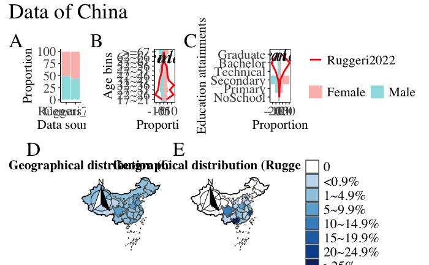

```r
fig1
```

# Nigeria Data

The data of Nigeria are from different sources.

For age and sex data, we extracted data from World bank, which has 2021 data.

The geographical data are from [wikipeida](https://en.wikipedia.org/wiki/Demographics_of_Nigeria).

The educational attainment data are from [DHS](https://dhsprogram.com/methodology/survey/survey-display-528.cfm)

## Sex ratio

```r
# Nigeria's data from Ruggeri
df_ng_ruggeri <- dat_unique %>%
  dplyr::filter(Residence == "Nigeria") %>%
  dplyr::select(ResponseId, Gender, EducationCompleted, Residence, Age, "Ethnic", "REGION" ) %>%
  dplyr::filter(Gender == "Female" | Gender == "Male")
# str(df_ng_wb)
# We will use the 2021 data
df_ng_census2021 <- df_ng_wb %>%
  dplyr::filter(`Country Name` == "Nigeria") %>%
  dplyr::select(1,3, 4, 9) %>%
  dplyr::rename("YR2021" = `2021 [YR2021]`) %>%
  dplyr::mutate(YR2021_num = as.numeric(YR2021)) %>%
  dplyr::filter(!is.na(YR2021_num))

df_ng_census2021_pop <-  df_ng_census2021 %>%
  dplyr::filter(!str_detect(`Series Name`,"%|\\(|-|\\d")) %>%
  dplyr::mutate(Cat = str_replace(`Series Name`, "Population, | population|,|Population in ", "")) %>%
  dplyr::mutate(Cat = str_replace(Cat, "largest city", "largest_city")) %>%
  dplyr::select(YR2021_num, Cat) %>%
  tidyr::pivot_wider(names_from = Cat, values_from = YR2021_num)

### Sex ratio
df_ng_census2021_sex <- df_ng_census2021_pop %>%
  dplyr::select(female, male) %>%
  tidyr::pivot_longer(female:male, names_to = "Sex", values_to = "N") %>%
  dplyr::mutate(Proportion = round(N / sum(N), 4) * 100,
                Source = "Census_2021",
                Sex = ifelse(Sex == "female", "Female", "Male"),
                Sex = factor(Sex, levels = c("Female", "Male"))) %>%
  dplyr::select(Source, Sex, Proportion)

df_ng_ruggeri_sex <- df_ng_ruggeri %>%
  dplyr::filter(Gender == "Female" | Gender == "Male") %>%
  dplyr::count(Gender) %>%
  dplyr::mutate(Proportion = round(n / sum(n), 4) * 100,
                Source = "Ruggeri_2022")  %>%
  dplyr::rename(Sex = Gender) %>%
  dplyr::select(Source, Sex, Proportion) %>%
  dplyr::mutate(Sex = ifelse(Sex == "Female", "Female", "Male"),
                Sex = factor(Sex, levels = c("Female", "Male")))

df_ng_sex_ratio <- rbind(df_ng_census2021_sex, df_ng_ruggeri_sex)

fig2a <- ggplot(df_ng_sex_ratio, aes(Source, Proportion,fill=Sex)) +
  geom_col(alpha = 0.5) +
  theme_classic()+
  xlab("Data sources") +
  theme(legend.position = "none",
        # legend.key.size = unit(20,"pt"),
        # legend.box.spacing = unit(4,"pt"),
        # legend.title = element_blank(),
        axis.title = element_text(size = 16, family = "serif"),
        # legend.text = element_text(size = 16, family = "serif"),
        axis.text = element_text(size =16, family = "serif"))

fig2a
```

## Age bins

```r
Age_bins_ng_all <- c("00-04", "05-09", "10-14", "15-19", "20-24", "25-29", "30-34", "35-39", "40-44", "45-49",
                 "50-54", "55-59", "60-64", "65-69", "70-74", "75-79","80-120")

Age_bins_ng_val <- c("15-19", "20-24", "25-29", "30-34", "35-39", "40-44", "45-49",
                 "50-54", "55-59", "60-64", "65-69", "70-74", "75-79","80-120")

Age_bins_ng_final <- c("15-19", "20-24", "25-29", "30-34", "35-39", "40-44", "45-49",
                       "50-54", "55-59", "60-64", ">=65")

df_ng_census2021_age <- df_ng_census2021 %>%
  dplyr::filter(str_detect(`Series Name`,"%")) %>%
  dplyr::filter(str_detect(`Series Name`,"ages")) %>%
  dplyr::mutate(Agebins = str_replace(`Series Name`, "Population ages ", "")) %>%
  dplyr::mutate(Agebins = str_replace(Agebins, " and above", "-120")) %>%
  dplyr::filter(str_detect(Agebins, "male")) %>%
  tidyr::separate(., col = Agebins, into = c("age", "sex", "note"), sep = ",|\\(") %>%
  dplyr::mutate(sex = str_replace_all(sex, "\\s", "")) %>% # remove all white space
  dplyr::mutate(note = str_replace(note, "\\)", "")) %>%
  dplyr::mutate(Percent = YR2021_num/100) %>%
  dplyr::mutate(sex = str_replace_all(sex, "\\s", "")) %>%
  dplyr::mutate(Pop = ifelse(sex == "female",
                             round(Percent * df_ng_census2021_pop$female, 0),
                             round(Percent * df_ng_census2021_pop$male,0)),
                Pop_percent = Pop/df_ng_census2021_pop$total) %>%
  dplyr::filter(age %in% Age_bins_ng_val) %>%
  dplyr::select(2,3,6,7, 11, 10, 1) %>%
  dplyr::mutate(ageBins = age) %>%
  dplyr::arrange(ageBins, sex) %>%
  dplyr::rename(Sex = sex,
                Proportion = Pop_percent) %>%
  dplyr::mutate(Proportion = Proportion * 100,
                Sex = ifelse(Sex == "male", "Male", "Female")) %>%
  dplyr::select(ageBins, Sex, Proportion)%>%
  dplyr::mutate(ageBins = ifelse(ageBins %in% Age_bins_ng_val[1:10], ageBins, # sum all above 65
                                 ">=65"),
                ageBins = factor(ageBins, levels = Age_bins_ng_final)) %>%
  dplyr::group_by(ageBins, Sex) %>%
  dplyr::summarise(Proportion = sum(Proportion)) %>%
  dplyr::ungroup()

df_ng_ruggeri_age <- df_ng_ruggeri %>%
  dplyr::filter(!is.na(Age)) %>%
    dplyr::mutate(ageBins = cut(Age,
                                breaks=c(15, 20, 25, 30, 35, 40, 45,
                                         50, 55, 60, 65, Inf),
                                labels=Age_bins_ng_final),
                ageBins = factor(ageBins,
                                 levels =Age_bins_ng_final)) %>%
  dplyr::mutate(Sex = as.character(Gender)) %>%
  dplyr::count(ageBins, Sex) %>%
  dplyr::mutate(Proportion = round(n / sum(n), 4) * 100) %>%
  tidyr::complete(ageBins, Sex, fill=list(Proportion=0)) %>%
  dplyr::mutate(Site = "Ruggeri_etal_2022")

fig2b <- ggplot(data = df_ng_census2021_age,
       aes(x=ageBins, y=ifelse(Sex=="Male", -Proportion, Proportion), fill=Sex)) +
  geom_col(alpha=0.5, width = 1) +
  geom_line(data = df_ng_ruggeri_age, aes(x=ageBins,
                                      y = ifelse(Sex == "Male", -Proportion, Proportion),
                                      group=Sex,color="Ruggeri2022"), size=1, inherit.aes = FALSE) +
  scale_y_continuous(limits = c(-21, 21)) +
  coord_flip() +
  labs(y="Proportion", x = "Age bins", color=NULL)+
  annotate("text",label= "italic(Male)", x=10,y=-10, parse=TRUE,size=8, family = "serif") +
  annotate("text",label= "italic(Female)", x=10,y=11, parse=TRUE,size=8,family = "serif") +
  scale_color_manual(values = c("red","blue"))+
  theme_classic()+
  theme(panel.border =element_rect(fill=NA,color="black"),
        legend.position ="bottom",
        legend.box.spacing = unit(2,"pt"),
        legend.text = element_text(size = 16, family = "serif"),
        legend.title = element_blank(),
        axis.title = element_text(size = 16,family = "serif"),
        axis.text = element_text(size = 16,family = "serif"))

fig2b
```

## Educational attainments

```r
### tried to use data from world bank, but did not find useful information
# ng_vars <- wb_search("^(?=.*education)(?=.*population)(?!.*25+).*", perl = TRUE)
#
# indcators <- ng_vars %>%
#   dplyr::filter(!str_detect(indicator_id, "HH.DHS.GAR.456|HH.DHS.NIR|HH.MICS.GAR|PRJ.ATT.2039.3|SE.PRE.NENR")) %>%
#   dplyr::filter(!str_detect(indicator_id,"SI.POV|UIS.AIR|UIS.GGR|UIS.NAR|UIS.NER|UIS.NIR|UIS.SLEN|UIS.XGOVEXP"))
#
# ng_vars_df <- wb_data(country = "NGA",
#                       indicator = indcators$indicator_id,
#                       # start_date = 2019, end_date = 2023,
#                       mrv = 1,
#                       return_wide = FALSE
#                       )
#
# ng_vars_df_2 <- ng_vars_df %>%
#   dplyr::select(where(~!all(is.na(.x)))) %>%
#   dplyr::filter(!str_detect(indicator, "Labor force"))
#
# ng_vars_Wittgenstein <- ng_vars_df_2 %>%
#   dplyr::filter(str_detect(indicator, "Wittgenstein")) %>%
#   dplyr::filter(!str_detect(indicator, "\\+|\\-|thousands")) %>%
#   dplyr::select(where(~!all(is.na(.x)))) %>%
#   dplyr::filter(str_detect(indicator, "Total"))
#
# ng_vars_UIS <- ng_vars_df_2 %>%
#   dplyr::filter(str_detect(indicator_id, "UIS")) %>%
#   dplyr::filter(!str_detect(indicator, "\\+|\\-|thousands")) %>%
#   dplyr::select(where(~!all(is.na(.x)))) %>%
#   dplyr::filter(str_detect(indicator, "Total"))

### using the data from DHS, page 44
#  Women and men age 15-49
## Nigeria's education,  6-3-3-4 system
# primary: 5/6 ~ 11/12
# Junior secondary: 11/12 ~ 14/15
# Senior Secondary: 14/15 ~ 17/18
# Tertiary institution (Uni, Polytech, MonoTech, College)
# ng_edu_prop <- data.frame(female = c(35, 4, 10, 16, 23, 11),
#                             male = c(22, 3, 11, 16, 32, 17),
#                           educ = c("No_Edu", "Some_Primary", "Complted primary", "Some_secondary",
#                                    "Completed_secondary", "More_than_secondary"))

df_ng_DHS2018_edu <- data.frame(Female = c(35, 14, 16, 23, 12), # originally sum up to 99, randomly added on to 100%
                                Male = c(22, 14, 16, 32, 16),   # originally sum up to 101
                                Edu = c("NoSchool", "Primary", "Some_secondary",
                                        "Secondary", "Tertiary")) %>%
  dplyr::mutate(Female = Female/2,
                Male = Male/2) %>%
  tidyr::pivot_longer(cols = Female:Male,names_to = "Sex", values_to = "Proportion") %>%
  dplyr::mutate(Sex = factor(Sex, levels = c("Female", "Male"))) %>%
  dplyr::mutate(Edu = factor(Edu,
                             levels = c("NoSchool", "Primary", "Some_secondary", "Secondary", "Tertiary"))) %>%
  dplyr::select(Sex, Edu, Proportion)

## Prepare data from Ruggeri et al (2022)
df_ng_ruggeri_edu <- df_ng_ruggeri %>%
  dplyr::filter(!is.na(EducationCompleted)) %>%
  dplyr::mutate(Edu = dplyr::case_when(EducationCompleted == "Bachelor" ~ "Tertiary",
                                       EducationCompleted == "Secondary ed." ~ "Secondary",
                                       EducationCompleted == "Technical ed." ~ "Tertiary",
                                       TRUE ~ "Other"
                                ),
                Edu = factor(Edu, levels = c("NoSchool", "Primary", "Some_secondary", "Secondary", "Tertiary"))) %>%
  dplyr::mutate(Gender = factor(Gender, levels = c("Female", "Male"))) %>%
  dplyr::rename(Sex = Gender) %>%
  dplyr::group_by(Sex, Edu) %>%
  dplyr::summarise(N = n()) %>%
  dplyr::ungroup() %>%
  dplyr::mutate(Proportion = round(N / sum(N), 4) * 100) %>%
  tidyr::complete(Sex, Edu,
                  fill = list(Proportion =0))%>%
  dplyr::select(Sex, Edu, Proportion)

fig2c <- ggplot(data= df_ng_DHS2018_edu,
                aes(x=Edu, y=ifelse(Sex=="Male", -Proportion, Proportion), fill=Sex)) +
  geom_col(alpha=0.5, width = 1) +
  geom_line(data = df_ng_ruggeri_edu,
            aes(x=Edu,
                y = ifelse(Sex == "Male", -Proportion, Proportion),
                group=Sex, color="Ruggeri2022"), size=1, inherit.aes = FALSE) +
  # scale_y_continuous(limits = c(-15,15), sec.axis = sec_axis(~.*1, name = "Proportion (Ruggeri2022)")) +
  coord_flip() +
  labs(y="Proportion", x = "Education attainments", color=NULL) +
  annotate("text",label= "italic(Male)", x=5,y=-20, parse=TRUE,size=8, family = "serif") +
  annotate("text",label= "italic(Female)", x=5,y=20, parse=TRUE,size=8,family = "serif") +
  scale_color_manual(values = c("red","blue")) +
  theme_classic() +
  theme(panel.border =element_rect(fill=NA,color="black"),
        legend.position ="bottom",
        legend.box.spacing = unit(2,"pt"),
        legend.text = element_text(size = 16, family = "serif"),
        legend.title = element_blank(),
        axis.title = element_text(size = 16,family = "serif"),
        axis.text = element_text(size = 16,family = "serif"))

fig2c
```

## Geo-distribution

```r
# copied from https://en.wikipedia.org/wiki/List_of_Nigerian_states_by_population#cite_note-2
# ng_data <- read_clip_tbl()
#
# ng_data <- ng_data %>%
#   dplyr::rename(Orders = 1)
#
# ng_data <- ng_data %>%
#   dplyr::rename(Pop_2006 = 3,
#                 Pop_2019 = 4)
#
# ng_data_new <- ng_data %>%
#   dplyr::mutate(State = str_remove(State, " State"),
#                 Orders = ifelse(Orders == "–", "37", Orders),
#                 Pop_2019 = str_remove_all(Pop_2019, ",")) %>%
#   dplyr::mutate(Pop_2019 = as.numeric(Pop_2019)) %>%
#   dplyr::filter(State != "Nigeria") %>%
#   dplyr::select(-Pop_2006) %>%
#   dplyr::mutate(Proportion = round(Pop_2019 / sum(Pop_2019), 3) * 100)
#
# write_csv(ng_data_new, "NG_pop_2019_wiki.csv", )

# extract Nigeria's data
# df_ng_ruggeri <- dat_unique %>%
#   dplyr::filter(Residence == "Nigeria") %>%
#   dplyr::select(ResponseId, Gender, EducationCompleted, Residence, Age, "Ethnic", "REGION" )

# library(remotes)
# remotes::install_github("wmgeolab/rgeoboundaries")
#
# df_ng_map <- rgeoboundaries::geoboundaries("Nigeria", "adm1") # need internet
#
# save(df_ng_map, file = here::here("Re_Analysis_NG.RData")) # save as rdata

load(here::here("Re_Analysis_NG.RData"))

df_ng_census2019_geo <- bruceR::import("NG_pop_2019_wiki.csv") %>%
  dplyr::select(State, Proportion) %>%
  dplyr::rename(state = State) %>%
  dplyr::arrange(state) %>%
  dplyr::mutate(PropBins = cut(Proportion,
                              breaks=c(0, 1, 5, 10, 15, 20, 25, 30),
                              labels=c("< 0.9%", "1~4.9%", "5~9.9%", "10~14.9%", "15~19.9%",
                                       "20~24.9%",">25%")),
                  PropBins = factor(PropBins,
                                    levels = c("0","< 0.9%", "1~4.9%", "5~9.9%", "10~14.9%", "15~19.9%",
                                               "20~24.9%",">25%")),
                  Colors = cut(Proportion,
                               breaks=c(0, 1, 5, 10, 15, 20, 25, 30),
                               labels=c("1", "2", "3", "4", "5","6","7")),
                  Colors = factor(Colors,
                                  levels = c("0","1", "2", "3", "4", "5","6","7")),
                  )

fig2d <- ggplot2::ggplot(data = df_ng_map, aes(fill = df_ng_census2019_geo$Colors)) +
  ggplot2::geom_sf(show.legend = TRUE) +
  scale_fill_manual("Proportions",
                    values = c("#FFFFFF", "#C6DBEF","#9ECAE1","#6BAED6",
                               "#4292C6", "#2171B5", "#08519C","#08306B"),
                    breaks = c("0","1",   "2", "3",
                               "4", "5", "6","7"),
                    labels = c("0",       "<0.9%",    "1~4.9%", "5~9.9%",
                               "10~14.9%", "15~19.9%", "20~24.9%",">25%"),
                    drop = FALSE,
      ) +
  labs(title = "Geographical distribution (Census data)") +
  theme(
        plot.title = element_text(
          color = "black",
          size = 16,
          face = "bold",
          vjust = 0.1,
          hjust = 0.5
        ),
        legend.title = element_blank(),
        # legend.position = "bottom",
        # legend.justification = "left",
        # legend.direction = "horizontal",
        legend.position =  c(0.9, 0.58), # position of legend
        legend.text=element_text(size=rel(1.5)),
        panel.grid = element_blank(),
        panel.background = element_blank(),
        axis.text = element_blank(),
        axis.ticks = element_blank(),
        axis.title = element_blank()
      ) +
  ## add north arrow, the style can be changed
      ggspatial::annotation_north_arrow(
        location = 'tl',
        which_north = 'false',
        style = ggspatial::north_arrow_fancy_orienteering()
      )

df_ng_ruggeri_geo <- df_ng_ruggeri %>%
  dplyr::filter(!is.na(REGION)) %>%
  dplyr::rename(state = REGION) %>%
  dplyr::mutate(state = as.character(state),
                state = ifelse(state == "Andamawa", "Adamawa", state)) %>% # correct two values that are not the name of states
  dplyr::arrange(state) %>%
  dplyr::group_by(state) %>%
  dplyr::summarise(state_n = n()) %>%
  dplyr::ungroup() %>%
  dplyr::mutate(Proportion = round(state_n / sum(state_n), 3) * 100) %>%
  dplyr::mutate(state = ifelse(state %in% naijR::states(), state, naijR::states()),
                state = factor(state, levels = naijR::states() )) %>%
  dplyr::mutate(PropBins = cut(Proportion,
                              breaks=c(0, 1, 5, 10, 15, 20, 25, 100),
                              labels=c("< 0.9%", "1~4.9%", "5~9.9%", "10~14.9%", "15~19.9%",
                                       "20~24.9%",">25%")),
                  PropBins = factor(PropBins,
                                    levels = c("0","< 0.9%", "1~4.9%", "5~9.9%", "10~14.9%", "15~19.9%",
                                               "20~24.9%",">25%")),
                  Colors = cut(Proportion,
                               breaks=c(0, 1, 5, 10, 15, 20, 25, 100),
                               labels=c("1", "2", "3", "4", "5","6","7")),
                  Colors = factor(Colors,
                                  levels = c("0","1", "2", "3", "4", "5","6","7")),
                  ) %>%
  tidyr::complete(state, fill = list(Proportion=0, PropBins = "0", Colors="0")) %>%
  dplyr::mutate(state = as.character(state))

fig2e <- ggplot2::ggplot(data = df_ng_map, aes(fill = df_ng_ruggeri_geo$Colors)) +
  ggplot2::geom_sf(show.legend = TRUE) +
  scale_fill_manual("Proportions",
                    values = c("#FFFFFF", "#C6DBEF","#9ECAE1","#6BAED6",
                               "#4292C6", "#2171B5", "#08519C","#08306B"),
                    breaks = c("0","1",   "2", "3",
                               "4", "5", "6","7"),
                    labels = c("0",       "<0.9%",    "1~4.9%", "5~9.9%",
                               "10~14.9%", "15~19.9%", "20~24.9%",">25%"),
                    drop = FALSE,
      ) +
  labs(title = "Geographical distribution (Ruggeri_2022)") +
  theme(
        plot.title = element_text(
          color = "black",
          size = 16,
          face = "bold",
          vjust = 0.1,
          hjust = 0.5
        ),
        legend.title = element_blank(),
        # legend.position = "bottom",
        # legend.justification = "left",
        # legend.direction = "horizontal",
        legend.position =  c(0.9, 0.58), # position of legend
        legend.text=element_text(size=rel(1.5)),
        panel.grid = element_blank(),
        panel.background = element_blank(),
        axis.text = element_blank(),
        axis.ticks = element_blank(),
        axis.title = element_blank()
      ) +
  ## add north arrow, the style can be changed
      ggspatial::annotation_north_arrow(
        location = 'tl',
        which_north = 'false',
        style = ggspatial::north_arrow_fancy_orienteering()
      )

# fig2de <- fig2d + fig2e + plot_layout(guides = "collect")
# fig2de

fig2 <- (fig2a + fig2b + fig2c + plot_layout(guides = "collect") ) /
  (fig2d + fig2e + plot_layout(guides = "collect")) +
  plot_annotation(tag_levels = 'A', title = "Data of Nigeria",
                  theme = theme(plot.title = element_text(size = 26))) +
  plot_layout(heights = c(1, 1.5)) &
  theme(plot.tag = element_text(size = 24),
        text = element_text("Times"))

ggsave("fig1_NG.pdf", fig2, device = "pdf", width=18, height = 15)
fig2
```

# US data

## sex ratio

```r
## data downloaded from: https://data.census.gov
df_us_census_age <- bruceR::import("ACSST5Y2021.S0101-2023-02-08T075713.csv") %>%
  dplyr::select(`Label (Grouping)`, contains("Estimate")) %>%
  dplyr::rename("ageBins" = 1, "Total" = 2, "Total_prop" = 3,
                "Male" = 4, "Male_prop" = 5, "Female" = 6, "Female_prop" = 7)%>%
  dplyr::select("ageBins", "Total", "Male", "Female") %>%
  dplyr::mutate(Total = as.integer(gsub(",", "", as.character(.$Total))),
                #Total_prop = as.numeric(gsub("%", "", as.character(.$Total_prop))),
                Male = as.integer(gsub(",", "", as.character(.$Male))),
                #Male_prop = as.numeric(gsub("%", "", as.character(.$Male_prop))),
                Female = as.integer(gsub(",", "", as.character(.$Female))),
                #Female_prop = as.numeric(gsub("%", "", as.character(.$Female_prop))),
                )
## sex ratio
df_us_census_sex <- df_us_census_age %>%
  dplyr::slice(1) %>%
  dplyr::mutate(Male = round(100*Male/Total, 1),
                Female = round(100*Female/Total, 1)) %>%
  dplyr::select(-Total) %>%
  tidyr::pivot_longer(cols = Male:Female,
                      names_to = "Sex",
                      values_to = "Proportion") %>%
  dplyr::rename(Site = ageBins) %>%
  dplyr::mutate(Site = "Census")

df_us_ruggeri2022 <- dat_unique %>%
  dplyr::filter(Residence == "United_States") %>%
  dplyr::select(ResponseId, Gender, EducationCompleted, Residence, Age, "Ethnic", "REGION" )

df_us_ruggeri_sex <- df_us_ruggeri2022 %>%
  dplyr::filter(Gender == "Female" | Gender == "Male") %>%
  dplyr::count(Gender) %>%
  dplyr::mutate(Proportion = round(n / sum(n), 4) * 100,
                Site = "Ruggeri2022") %>%
  dplyr::select(Site, Gender, Proportion) %>%
  dplyr::rename(Sex = Gender)

df_us_sex_ratio <- rbind(df_us_census_sex, df_us_ruggeri_sex) %>%
  dplyr::mutate(Sex = factor(Sex, levels = c("Female", "Male")),
                Site = factor(Site, levels = c("Census", "Ruggeri2022")))

fig3a <- ggplot(df_us_sex_ratio, aes(Site, Proportion,fill=Sex)) +
  geom_col(alpha=0.5)+
  theme_classic()+
  #coord_flip() +
  xlab("Data sources") +
  theme(legend.position = "none",
        #legend.key.size = unit(20,"pt"),
        #legend.box.spacing = unit(4,"pt"),
        #legend.title = element_blank(),
        axis.title = element_text(size = 16, family = "serif"),
        #legend.text = element_text(size = 16, family = "serif"),
        axis.text = element_text(size =16, family = "serif"))

fig3a
```

```r
## age bins
df_us_census_age_all <- df_us_census_age %>%
  dplyr::slice(3:15, 32) %>%
  dplyr::mutate(Male = round(100*Male/sum(Total), 1),
                Female = round(100*Female/sum(Total), 1)) %>%
  dplyr::slice(4:14) %>%
  dplyr::mutate(ageBins = Age_bins_ng_final,
                ageBins = factor(ageBins, levels = Age_bins_ng_final)) %>%
  dplyr::select(ageBins,Male,Female) %>%
  tidyr::pivot_longer(cols = Male:Female,
                      names_to = 'Sex',
                      values_to = "Proportion") %>%
  dplyr::mutate(Sex = factor(Sex, levels = c("Female", "Male")))

df_us_ruggeri2022_age <- df_us_ruggeri2022 %>%
  dplyr::filter(Gender == "Female" | Gender == "Male") %>%
  dplyr::filter(!is.na(Age)) %>%
    dplyr::mutate(ageBins = cut(Age,
                                  breaks=c(15, 20, 25, 30, 35, 40, 45,
                                           50, 55, 60, 65, Inf),
                                  labels=Age_bins_ng_final),
                ageBins = factor(ageBins,
                                     levels =Age_bins_ng_final)) %>%
  dplyr::mutate(Sex = as.character(Gender)) %>%
  dplyr::count(ageBins, Sex) %>%
  dplyr::mutate(Proportion = round(n / sum(n), 4) * 100) %>%
  tidyr::complete(ageBins, Sex, fill=list(Proportion=0)) %>%
  dplyr::mutate(Site = "Ruggeri_etal_2022",
                Sex = factor(Sex, levels = c("Female", "Male")))

fig3b <- ggplot(data = df_us_census_age_all, aes(x=ageBins, y=ifelse(Sex=="Male", -Proportion, Proportion), fill=Sex)) +
  geom_col(alpha=0.5, width = 1) +
  geom_line(data = df_us_ruggeri2022_age,
            aes(x=ageBins,
                y = ifelse(Sex == "Male", -Proportion, Proportion),
                group=Sex, color="Ruggeri2022"), size=1, inherit.aes = FALSE) +
  scale_y_continuous(limits = c(-15, 15)) +
  coord_flip() +
  labs(y="Proportion", x = "Age bins", color=NULL)+
  annotate("text",label= "italic(Male)", x=10,y=-7, parse=TRUE,size=8, family = "serif") +
  annotate("text",label= "italic(Female)", x=10,y=8, parse=TRUE,size=8,family = "serif") +
  scale_color_manual(values = c("red","blue"))+
  theme_classic()+
  theme(panel.border =element_rect(fill=NA,color="black"),
        legend.position ="bottom",
        legend.box.spacing = unit(2,"pt"),
        legend.text = element_text(size = 16, family = "serif"),
        legend.title = element_blank(),
        axis.title = element_text(size = 16,family = "serif"),
        axis.text = element_text(size = 16,family = "serif"))
fig3b
```

```r
### education:
# American Community Survey
# B15001SEX BY AGE BY EDUCATIONAL ATTAINMENT FOR THE POPULATION 18 YEARS AND OVER
# 2021: ACS 5-Year Estimates Detailed Tables
df_us_census_edu <- bruceR::import("ACSDT5Y2021.B15001-2023-02-08T135043.csv") %>%
  dplyr::select(`Label (Grouping)`, contains("Estimate")) %>%
  dplyr::rename(Label = 1,
                Estimate = 2) %>%
  dplyr::mutate(Estimate = as.integer(gsub(",", "", as.character(.$Estimate))),
                #Label = str_remove_all(Label, " ")
                )

df_us_census_edu_all <- df_us_census_edu %>%
  dplyr::slice(-c(1, 2, 43)) %>%
  dplyr::mutate(Sex = rep(c("Male", "Female"), each=40),
                Label = str_trim(Label, side = "both")) %>% # find this function took me > 20 minutes.
  dplyr::mutate(Edu = dplyr::case_when(Label == "Less than 9th grade" ~ "Primary",
                                       Label == "9th to 12th grade, no diploma" ~ "Primary",
                                       Label == "High school graduate (includes equivalency)" ~ "Secondary",
                                       Label == "Some college, no degree" ~ "Secondary",
                                       Label == "Bachelor's degree" ~ "Bachelor",
                                       Label == "Graduate or professional degree" ~ "Graduate",
                                       TRUE ~ "Other"
                                       ),
                ageBins = rep(rep(c("18-24", "25-34", "35-44","45-64", ">=65"), each=8), 2)) %>%
  dplyr::filter(Edu != "Other") %>%
  dplyr::group_by(Sex, Edu) %>%
  dplyr::summarise(N = sum(Estimate)) %>%
  dplyr::ungroup() %>%
  dplyr::mutate(Edu = factor(Edu,
                             levels = c("NoSchool", "Primary", "Secondary",
                                        "Bachelor", "Graduate")),
                Sex = factor(Sex, levels = c("Female", "Male"))) %>%
  dplyr::arrange(Sex, Edu) %>%
  tidyr::complete(Sex, Edu,
                  fill = list(N =0)) %>%
  dplyr::mutate(Proportion = round(N / sum(N), 4) * 100,
                Source = "Census_2021")

df_us_ruggeri_edu <- df_us_ruggeri2022 %>%
  dplyr::filter(Gender == "Female" | Gender == "Male") %>%
  dplyr::filter(!is.na(EducationCompleted)) %>%
  dplyr::mutate(Edu = dplyr::case_when(EducationCompleted  == "MBA" ~ "Graduate",
                                EducationCompleted  == "PhD" ~ "Graduate",
                                EducationCompleted  == "Graduate" ~ "Graduate",
                                EducationCompleted  == "Primary ed." ~ "Primary",
                                EducationCompleted  == "Secondary ed." ~ "Secondary",
                                EducationCompleted  == "Technical ed." ~ "Bachelor",
                                EducationCompleted  == "Bachelor" ~ "Bachelor",
                                )) %>%
  dplyr::group_by(Gender, Edu) %>%
  dplyr::summarise(N = n()) %>%
  dplyr::ungroup() %>%
  dplyr::rename(Sex = Gender) %>%
  dplyr::mutate(Edu = factor(Edu, levels = c("NoSchool", "Primary", "Secondary",
                                        "Bachelor", "Graduate")),
                Sex = factor(Sex, levels = c("Female", "Male"))) %>%
  tidyr::complete(Sex, Edu,
                  fill = list(N =0)) %>%
  dplyr::mutate(Proportion = round(N / sum(N), 4) * 100,
                Source = "Ruggeri_2022")

df_us_edu <- rbind(df_us_ruggeri_edu, df_us_census_edu_all)

# tried to use col plot, not used in the end
ggplot(df_us_edu, aes(x=Proportion, y=Source, fill=Edu)) +
  geom_col(alpha = .75)+
  labs(y="Sex") +
  scale_fill_discrete(label=c("NoSchool", "Primary", "Secondary", "Bachelor", "Graduate")) +
  theme_classic() +
  # guides(y="axis_nested") +
  theme(legend.title = element_text(size = 15,family = "serif"),
        axis.title= element_text(size = 15,family = "serif"),
        axis.text = element_text(size = 10,family = "serif"),
        strip.text = element_text(size = 15,family = "serif"),
        strip.background = element_rect(fill = NA,color = NA),
        panel.border = element_rect(fill = NA,color = "black")) +
  scale_x_continuous(breaks = seq(0, 1, by = 0.1)) +
  facet_wrap(~ Sex, scales = "free")

fig3c <- ggplot(data= df_us_census_edu_all, aes(x=Edu, y=ifelse(Sex=="Male", -Proportion, Proportion), fill=Sex)) +
  geom_col(alpha=0.5, width = 1) +
  geom_line(data = df_us_ruggeri_edu,
            aes(x=Edu,
                y = ifelse(Sex == "Male", -Proportion, Proportion),
                group=Sex, color="Ruggeri2022"), size=1, inherit.aes = FALSE) +
  # scale_y_continuous(limits = c(-15,15), sec.axis = sec_axis(~.*1, name = "Proportion (Ruggeri2022)")) +
  coord_flip() +
  labs(y="Proportion", x = "Education attainments", color=NULL) +
  annotate("text",label= "italic(Male)", x=5,y=-15, parse=TRUE,size=8, family = "serif") +
  annotate("text",label= "italic(Female)", x=5,y=15, parse=TRUE,size=8,family = "serif") +
  scale_color_manual(values = c("red","blue")) +
  theme_classic() +
  theme(panel.border =element_rect(fill=NA,color="black"),
        legend.position ="bottom",
        legend.box.spacing = unit(2,"pt"),
        legend.text = element_text(size = 16, family = "serif"),
        legend.title = element_blank(),
        axis.title = element_text(size = 16,family = "serif"),
        axis.text = element_text(size = 16,family = "serif"))

# fig3_abc <- fig3a + fig3b + fig3c + plot_annotation(tag_levels = 'A')#  + plot_layout(heights = c(1, 1.3))
#
# ggsave("fig3_abc_USData.pdf", fig3_abc, device = "pdf", width=15, height = 9)

fig3c
```

```r
# census_api_key("", install = TRUE, overwrite=TRUE)
# readRenviron("~/.Renviron")
#
# us_median_age <- get_acs(
#   geography = "state",
#   variables = "B01002_001",
#   year = 2019,
#   survey = "acs1",
#   geometry = TRUE,
#   resolution = "20m"
# ) %>%
#   shift_geometry()
# df_us_map <- us_median_age # data downloaded from gov
# save(df_us_map, file = here::here("Re_Analysis_USA.RData"))

df_us_census_geo <- bruceR::import("DECENNIALPL2020.P1-2023-02-08T080125.csv") %>%
  dplyr::slice(1) %>%
  tidyr::pivot_longer(cols = "Alabama":"Puerto Rico",
                      names_to = "State",
                      values_to = "Pop") %>%
  dplyr::select(State, Pop) %>%
  dplyr::mutate(Pop = as.integer(gsub(",", "", as.character(.$Pop)))) %>%
  dplyr::mutate(Proportion = round(Pop / sum(Pop), 4) * 100,
                Source = "Cenesus_2020") %>%
  dplyr::mutate(PropBins = cut(Proportion,
                              breaks=c(0, 1, 5, 10, 15, 20, 25, 100),
                              labels=c("< 0.9%", "1~4.9%", "5~9.9%", "10~14.9%", "15~19.9%",
                                       "20~24.9%",">25%")),
                  PropBins = factor(PropBins,
                                    levels = c("0","< 0.9%", "1~4.9%", "5~9.9%", "10~14.9%", "15~19.9%",
                                               "20~24.9%",">25%")),
                  Colors = cut(Proportion,
                               breaks=c(0, 1, 5, 10, 15, 20, 25, 100),
                               labels=c("1", "2", "3", "4", "5","6","7")),
                  Colors = factor(Colors,
                                  levels = c("0","1", "2", "3", "4", "5","6","7"))
                ) %>%
  dplyr::arrange(State)

# df_census_us_geo_p <- us_median_age %>%
#   dplyr::arrange(NAME) %>%
#   dplyr::mutate(Proportion = df_us_census_geo$Proportion,
#                 propBins = df_us_census_geo$propBins)

df_us_ruggeri_geo <- df_us_ruggeri2022 %>%
  dplyr::filter(!is.na(REGION)) %>%
  dplyr::group_by(REGION) %>%
  dplyr::summarise(N = n()) %>%
  dplyr::ungroup() %>%
  dplyr::filter(REGION %in% df_us_census_geo$State) %>%
  dplyr::mutate(Proportion = round(N / sum(N), 4) * 100,
                Source = "Ruggeri_2022") %>%
  dplyr::mutate(PropBins = cut(Proportion,
                              breaks=c(0, 1, 5, 10, 15, 20, 25, 100),
                              labels=c("< 0.9%", "1~4.9%", "5~9.9%", "10~14.9%", "15~19.9%",
                                       "20~24.9%",">25%")),
                  PropBins = factor(PropBins,
                                    levels = c("0","< 0.9%", "1~4.9%", "5~9.9%", "10~14.9%", "15~19.9%",
                                               "20~24.9%",">25%")),
                  Colors = cut(Proportion,
                               breaks=c(0, 1, 5, 10, 15, 20, 25, 100),
                               labels=c("1", "2", "3", "4", "5","6","7")),
                  Colors = factor(Colors,
                                  levels = c("0","1", "2", "3", "4", "5","6","7"))
                ) %>%
  dplyr::arrange(Proportion) %>%
  dplyr::mutate(REGION = factor(REGION,
                                levels = df_us_census_geo$State)) %>%
  tidyr::complete(REGION, fill = list(PropBins="0", Colors = "0"))

df_us_ruggeri_geo_p <- df_us_map %>%
  dplyr::arrange(NAME) %>%
  dplyr::mutate(Proportion = df_us_ruggeri_geo$Proportion,
                propBins = df_us_ruggeri_geo$propBins)

fig3d <- ggplot(data = df_us_map, aes(fill = df_us_census_geo$Colors)) +
  geom_sf() +
  scale_fill_manual("Proportions",
                    values = c("#FFFFFF", "#C6DBEF","#9ECAE1","#6BAED6",
                               "#4292C6", "#2171B5", "#08519C","#08306B"),
                    breaks = c("0","1",   "2", "3",
                               "4", "5", "6","7"),
                    labels = c("0",       "<0.9%",    "1~4.9%", "5~9.9%",
                               "10~14.9%", "15~19.9%", "20~24.9%",">25%"),
                    drop = FALSE,
      ) +
  labs(title = "Geographical distribution (Census)",
       #caption = "Data source: 2020 DECENNIALPL, US Census Bureau",
       ) +
  theme(
        plot.title = element_text(
          color = "black",
          size = 16,
          face = "bold",
          vjust = 0.1,
          hjust = 0.5
        ),
        legend.title = element_blank(),
        # legend.position = "bottom",
        # legend.justification = "left",
        # legend.direction = "horizontal",
        legend.position =  c(0.9, 0.58), # position of legend
        legend.text=element_text(size=rel(1.5)),
        panel.grid = element_blank(),
        panel.background = element_blank(),
        axis.text = element_blank(),
        axis.ticks = element_blank(),
        axis.title = element_blank()
      ) +
  ## add north arrow, the style can be changed
      ggspatial::annotation_north_arrow(
        location = 'tl',
        which_north = 'false',
        style = ggspatial::north_arrow_fancy_orienteering()
      )

fig3e <- ggplot(data = df_us_map, aes(fill = df_us_ruggeri_geo$Colors)) +
  geom_sf() +
    scale_fill_manual("Proportions",
                    values = c("#FFFFFF", "#C6DBEF","#9ECAE1","#6BAED6",
                               "#4292C6", "#2171B5", "#08519C","#08306B"),
                    breaks = c("0","1",   "2", "3",
                               "4", "5", "6","7"),
                    labels = c("0",       "<0.9%",    "1~4.9%", "5~9.9%",
                               "10~14.9%", "15~19.9%", "20~24.9%",">25%"),
                    drop = FALSE,
      )  +
  labs(title = "Geographical distribution (Ruggeri)") +
  theme(
        plot.title = element_text(
          color = "black",
          size = 16,
          face = "bold",
          vjust = 0.1,
          hjust = 0.5
        ),
        legend.title = element_blank(),
        # legend.position = "bottom",
        # legend.justification = "left",
        # legend.direction = "horizontal",
        legend.position =  c(0.9, 0.58), # position of legend
        legend.text=element_text(size=rel(1.5)),
        panel.grid = element_blank(),
        panel.background = element_blank(),
        axis.text = element_blank(),
        axis.ticks = element_blank(),
        axis.title = element_blank()
      ) +
  ## add north arrow, the style can be changed
      ggspatial::annotation_north_arrow(
        location = 'tl',
        which_north = 'false',
        style = ggspatial::north_arrow_fancy_orienteering()
      )

fig3 <- (fig3a + fig3b + fig3c + plot_layout(guides = "collect") ) /
  (fig3d + fig3e + plot_layout(guides = "collect")) +
  plot_annotation(tag_levels = 'A', title = "Data of United States",
                  theme = theme(plot.title = element_text(size = 26))) +
  plot_layout(heights = c(1, 1.5)) &
  theme(plot.tag = element_text(size = 24),
        text = element_text("Times"))

ggsave("fig1_US.pdf", fig3, device = "pdf", width=18, height = 15)
fig3
```